## Predicting correct execution of weight lifting exercises

### Summary

Having an application displaying if an specific exercise is executed correctly can be very useful for sports practitioners. Using data from [Groupware@LES](http://groupware.les.inf.puc-rio.br/), which recorded the execution of weight lifting from six participant perfoming the activity in different ways.

A random forest was used with as separated cross-validation set to evaluate the predictions. An 0.02% out of sample error rate was achieved.

### The data. Exploratory analysis

The data is composed of 19622 observations and 160 features. The most part of them are meassurements from a gyroscope and an accelerometer derived from different movements of the participants. The features corresponding to a aggregation of this meassurements are mostly NAs or blank spaces. There are five different ways of performing an exercise (one of them is correct) labeled in the variable “classe” as A, B, C, D, E.

```r
training<-read.csv("http://d396qusza40orc.cloudfront.net/predmachlearn/pml-training.csv", nrows=20)
head(training[,grep("avg", names(training))],10)
```

```
##    avg_roll_belt avg_pitch_belt avg_yaw_belt avg_roll_arm avg_pitch_arm
## 1             NA             NA           NA           NA            NA
## 2             NA             NA           NA           NA            NA
## 3             NA             NA           NA           NA            NA
## 4             NA             NA           NA           NA            NA
## 5             NA             NA           NA           NA            NA
## 6             NA             NA           NA           NA            NA
## 7             NA             NA           NA           NA            NA
## 8             NA             NA           NA           NA            NA
## 9             NA             NA           NA           NA            NA
## 10            NA             NA           NA           NA            NA
##    avg_yaw_arm avg_roll_dumbbell avg_pitch_dumbbell avg_yaw_dumbbell
## 1           NA                NA                 NA               NA
## 2           NA                NA                 NA               NA
## 3           NA                NA                 NA               NA
```

[output cut: 18 more lines]

So, the data is readed specifying blank spaces as NAs.

```r
training<-read.csv("http://d396qusza40orc.cloudfront.net/predmachlearn/pml-training.csv", na.strings=c(NA, ""))
missing_values<-sum(is.na(training))
```

There is a total of 1921600 missing values. The total number of missing values in each column happens to be always the same: 19216 (sample of the output below), this is, about a 98% of the total number of observations. We opt for removing these features.

```r
apply(training, 2, function(x){sum(is.na(x))})[sample(1:20)]
```

```
##         max_yaw_belt           new_window    skewness_yaw_belt
##                19216                    0                19216
##            user_name   kurtosis_roll_belt       cvtd_timestamp
##                    0                19216                    0
## raw_timestamp_part_2       max_picth_belt     total_accel_belt
##                    0                19216                    0
##             yaw_belt  kurtosis_picth_belt                    X
##                    0                19216                    0
##   skewness_roll_belt           pitch_belt skewness_roll_belt.1
##                19216                    0                19216
##    kurtosis_yaw_belt        max_roll_belt raw_timestamp_part_1
##                19216                19216                    0
##            roll_belt           num_window
##                    0                    0
```

```r
nonNAcolumns<-names(training)[apply(training, 2, function(x) sum(is.na(x)))<19216]
training<-training[,nonNAcolumns]
```

Some other variables are removed from the data set: the first one, “X”, which is row identifier; the user name, and the date/time and timestamp related variables. The date/time variable is almost perfectly correlated with the user.It identifies the day and time when the activity was recorded. We cannot extract useful information from the timestamp variables. So we remove them all.

```r
with(training, table(user_name, cvtd_timestamp))
```

```
##           cvtd_timestamp
## user_name  02/12/2011 13:32 02/12/2011 13:33 02/12/2011 13:34
##   adelmo                177             1321             1375
##   carlitos                0                0                0
##   charles                 0                0                0
##   eurico                  0                0                0
##   jeremy                  0                0                0
##   pedro                   0                0                0
##           cvtd_timestamp
## user_name  02/12/2011 13:35 02/12/2011 14:56 02/12/2011 14:57
##   adelmo               1019                0                0
##   carlitos                0                0                0
##   charles                 0              235             1380
##   eurico                  0                0                0
##   jeremy                  0                0                0
##   pedro                   0                0                0
##           cvtd_timestamp
## user_name  02/12/2011 14:58 02/12/2011 14:59 05/12/2011 11:23
##   adelmo                  0                0                0
##   carlitos                0                0              190
##   charles              1364              557                0
##   eurico                  0                0                0
##   jeremy                  0                0                0
##   pedro                   0                0                0
##           cvtd_timestamp
## user_name  05/12/2011 11:24 05/12/2011 11:25 05/12/2011 14:22
##   adelmo                  0                0                0
##   carlitos             1497             1425                0
##   charles                 0                0                0
##   eurico                  0                0                0
##   jeremy                  0                0                0
##   pedro                   0                0              267
##           cvtd_timestamp
## user_name  05/12/2011 14:23 05/12/2011 14:24 28/11/2011 14:13
##   adelmo                  0                0                0
##   carlitos                0                0                0
##   charles                 0                0                0
##   eurico                  0                0              833
##   jeremy                  0                0                0
##   pedro                1370              973                0
##           cvtd_timestamp
## user_name  28/11/2011 14:14 28/11/2011 14:15 30/11/2011 17:10
##   adelmo                  0                0                0
##   carlitos                0                0                0
##   charles                 0                0                0
##   eurico               1498              739                0
##   jeremy                  0                0              869
##   pedro                   0                0                0
##           cvtd_timestamp
## user_name  30/11/2011 17:11 30/11/2011 17:12
##   adelmo                  0                0
##   carlitos                0                0
##   charles                 0                0
##   eurico                  0                0
##   jeremy               1440             1093
##   pedro                   0                0
```

```r
training<-training[,-c(1,3:5)]
```

#### Data partition

```r
set.seed(121)
inTrain<-createDataPartition(y=training$classe, p=0.7, list=FALSE)
training<-training[inTrain,]
cv<-training[-inTrain,]
```

#### Extreme values

Some extreme values were found in the data set, wich are represented in the figure below. These extreme values make more difficult (or impossible) the task of visually identifying patterns in the data. Observations corresponding to the extreme values are removed from the data set.

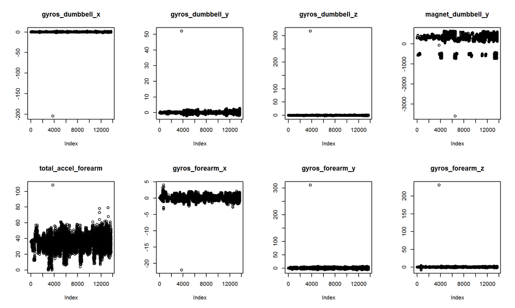

```r
par(mfrow=c(2,4))
for (idx in c(34, 35, 36, 41, 46, 47, 48, 49)){
  plot(training[,idx], main=names(training)[idx], ylab="")
}
```

```r
extreme.obs<-c(which.min(training[,34]),
  which.max(training[,35]),
  which.max(training[,36]),
  which.max(training[,37]),
  which.min(training[,41]),
  which.max(training[,46]),
  which.min(training[,47]),
  which.max(training[,48]),
  which.max(training[,49]))
training<-training[-unique(extreme.obs),]
```

#### Patterns in the data

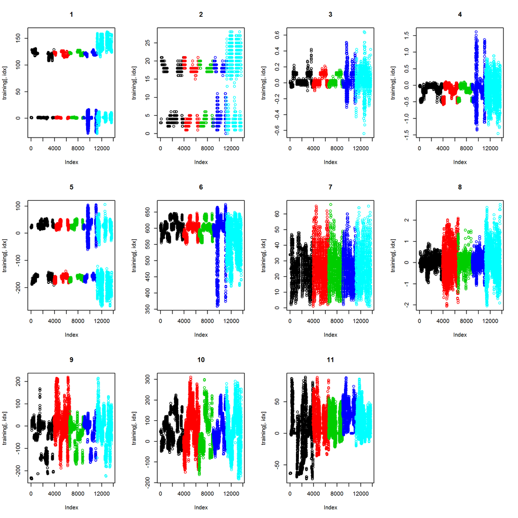

```r
par(mfrow=c(3,4))
title=1
for (idx in c(4,7,9,10,13,15,20,35,37,38,44)){
  plot(training[,idx], col=training$classe, main=title)
  title=title+1
}
```

As we cas see is easy to find patterns which distinguish the two tones of blue (clases D and E) from the rest. We can also find patters which distinguish the B class (color red) from the rest in figures 8 and 9. Class A (color black) is also different from the rest in figures 7, 10, and 11. No clear patters were found for classe C (color green).

### Model

```r
library(randomForest)
modFit<-randomForest(classe~., data=training)
modFit
```

```
##
## Call:
##  randomForest(formula = classe ~ ., data = training)
##                Type of random forest: classification
##                      Number of trees: 500
## No. of variables tried at each split: 7
##
##         OOB estimate of  error rate: 0.23%
## Confusion matrix:
##      A    B    C    D    E class.error
## A 3905    0    0    0    0    0.000000
## B    2 2653    1    0    0    0.001130
## C    0    8 2388    0    0    0.003339
## D    0    0   15 2236    1    0.007105
## E    0    0    0    4 2521    0.001584
```

As one can see from the confusion matrix, the error rate in the training set is a very low one: 0.0023. However this is an optimistic estimation of the error of the model. Now we confront the model predictions with a cross validation set. First we split the data of this set into 5 folds. Then we predict the model on that 5 folds and create 5 confusion matrices

```r
folds<-createFolds(y=cv$classe, k=5, returnTrain=FALSE)
matr<-list(vector("list",5))
for (idx in 1:5){
classe.cv<-cv[folds[[idx]],"classe"]
cross<-cv[folds[[idx]],-56]
pred<-predict(modFit, cross)
conf<-table(pred, classe.cv)
matr[[idx]]<-conf}
matr
```

```
## [[1]]
##     classe.cv
## pred   A   B   C   D   E
##    A 235   0   0   0   0
##    B   0 155   0   0   0
##    C   0   0 147   0   0
##    D   0   0   0 134   0
##    E   0   0   0   0 153
##
## [[2]]
##     classe.cv
## pred   A   B   C   D   E
##    A 235   0   0   0   0
##    B   0 155   0   0   0
##    C   0   0 146   0   0
##    D   0   0   0 135   0
##    E   0   0   0   0 153
##
## [[3]]
##     classe.cv
## pred   A   B   C   D   E
##    A 235   0   0   0   0
##    B   0 155   0   0   0
##    C   0   0 146   0   0
##    D   0   0   0 134   0
##    E   1   0   0   0 154
##
## [[4]]
##     classe.cv
## pred   A   B   C   D   E
##    A 235   0   0   0   0
##    B   0 156   0   0   0
##    C   0   0 147   0   0
##    D   0   0   0 135   0
##    E   0   0   0   0 153
##
## [[5]]
##     classe.cv
## pred   A   B   C   D   E
##    A 235   0   0   0   0
##    B   0 156   0   0   0
##    C   0   0 147   0   0
##    D   0   0   0 134   0
##    E   0   0   0   0 154
```

As can be seen in the confusion matrices,there is only one classification error. In matrix 3, one observation is predicted to be in class E when, in fact belongs to class A.That give us a 0.02% error rate in the cross validation set. This is the expected error rate for predictions using this model.

### Conclusions

A 0.02% out of sample error rate may seem quite impossible. However, the error rate from the training set is 0.2%. In any case, here is the report for anyone who could be interested in reproducing the analysis. If there are no errors in the procedure, this is undoubtedly a very good algorithm for predicting when a correct execution of the weight lifting exercise is performed.